# sangr_usage

```r
library(sangr)
library(tidyverse)
theme_set(theme_classic(base_size=16))
```

The `sangr` package is used to simulate Sanger sequencing chromatograms. The simulated chromatograms are designed to be used for illustrative purposes - they are not an exact mathematical model of real sanger data but are intended to be visually similar.

The package has two types of functions:

1. Functions which generate probability density values for the different base traces
2. A function `draw_chromatogram` which takes the probabilities and plots them

# Generating probabilities

The main function for generating base probability data is the `simulate_sanger_data` function. This takes in a string containing a sequence to simulate and generates a set of probabilities which can then be passed to `draw_chromatogram` to get a visual version of a trace.

The basic usage of the function just requires a sequence:

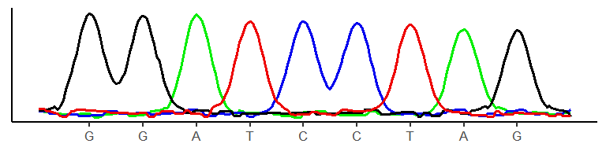

```r
simulate_sanger_data("GGATCCTAG") %>%
  draw_chromatogram()
```

## Peak Resolution

You can vary the resolution of the peaks by changing the `sd` parameter. Each base occupies 20 positions and the default `sd` is 5

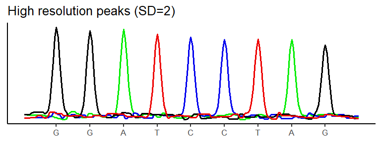

```r
simulate_sanger_data("GGATCCTAG", sd=2) %>%
  draw_chromatogram() +
  ggtitle("High resolution peaks (SD=2)")
```

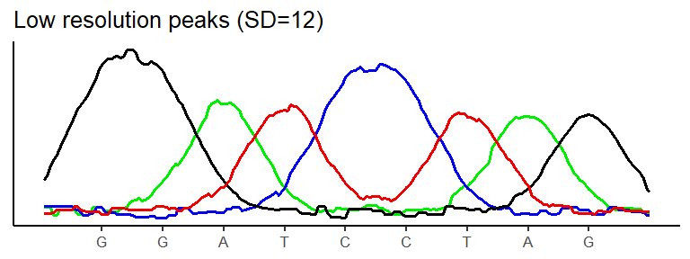

```r
simulate_sanger_data("GGATCCTAG", sd=12) %>%
  draw_chromatogram() +
  ggtitle("Low resolution peaks (SD=12)")
```

## Noise

You can add varying amounts of random noise to the traces using the `noise` parameter. Sensible values for noise go from 0 (completley clean), to 1 (very high noise) and above.

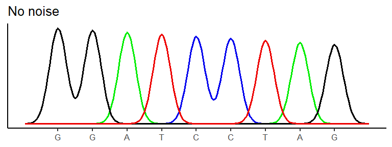

```r
simulate_sanger_data("GGATCCTAG", noise=0) %>%
  draw_chromatogram() +
  ggtitle("No noise")
```

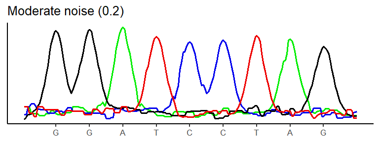

```r
simulate_sanger_data("GGATCCTAG", noise=0.2) %>%
  draw_chromatogram() +
  ggtitle("Moderate noise (0.2)")
```

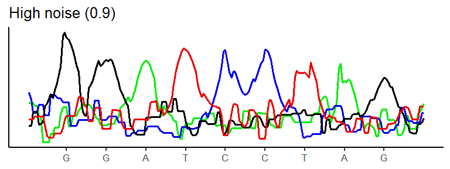

```r
simulate_sanger_data("GGATCCTAG", noise=0.9) %>%
  draw_chromatogram() +
  ggtitle("High noise (0.9)")
```

## Signal Degradation

Another factor you can change is how much the signal degrades over the course of the sequence. Real chromatograms will show a loss of signal as they proceed and you can simulate that using the `degrade` option. You specify the proportion of signal which remains by the end of the trace, so `degrade=0.6` means that the last base will retain only 60% of the signal in the first base.

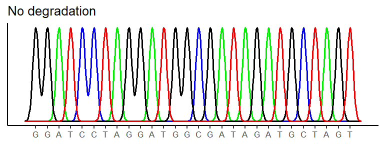

```r
simulate_sanger_data("GGATCCTAGGATGGCGATAGATGCTAGT", noise=0, degrade=1) %>%
  draw_chromatogram() +
  ggtitle("No degradation")
```

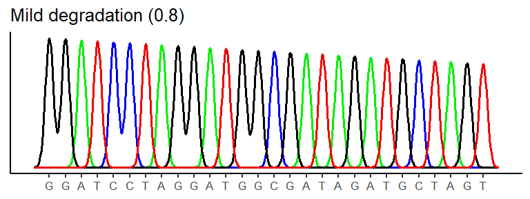

```r
simulate_sanger_data("GGATCCTAGGATGGCGATAGATGCTAGT", noise=0, degrade=0.8) %>%
  draw_chromatogram("GGATCCTAGGATGGCGATAGATGCTAGT") +
  ggtitle("Mild degradation (0.8)")
```

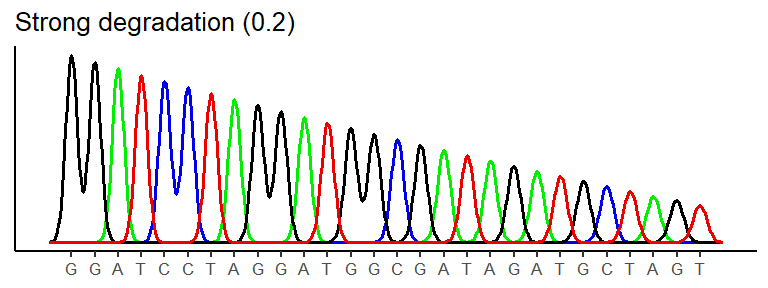

```r
simulate_sanger_data("GGATCCTAGGATGGCGATAGATGCTAGT", noise=0, degrade=0.2) %>%
  draw_chromatogram("GGATCCTAGGATGGCGATAGATGCTAGT") +
  ggtitle("Strong degradation (0.2)")
```

# Combining Probabilities

If you have run the `simulate_sanger_data` function multiple times you might want to demonstrate the effect of having a mixed signal in your traces. You can therefore use the `merge_sanger_data` function to merge multiple sets of probability together so that they can be plotted.

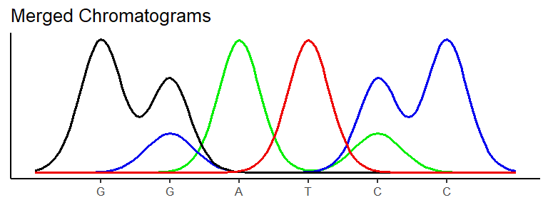

```r
simulate_sanger_data("GGATCC", noise=0, degrade=1) -> sanger1
simulate_sanger_data("GCATCC", noise=0, degrade=1, sd=7) -> sanger2
simulate_sanger_data("GGATAC", noise=0, degrade=1, sd=7) -> sanger3

merge_sanger_data(sanger1, sanger2, sanger3) %>%
  draw_chromatogram() +
  ggtitle("Merged Chromatograms")
```

# Drawing Chromatograms

The `draw_chromatogram` function turns a set of probabilities into a drawn chromatogram. The returned value is a `ggplot2` object containing a line graph of the chromatogram. By default the function will call bases based on the strongest signal at each position in the trace.

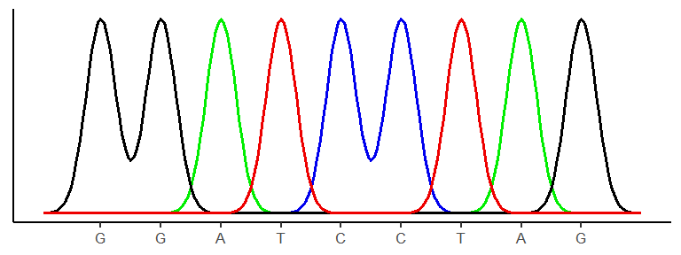

```r
simulate_sanger_data("GGATCCTAG", noise=0, degrade=1) -> sangr_data

draw_chromatogram(sangr_data)
```

## Customising colours

Different systems use different colours to represent the different DNA bases. We provide some standard colour schemes and also allow you to specify your own if you prefer.

The default scheme is the one used by ABI in their viewers.

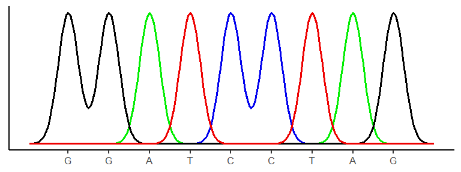

```r
draw_chromatogram(sangr_data, palette = "ABI")
```

We also include the colours used by Geneious Prime.

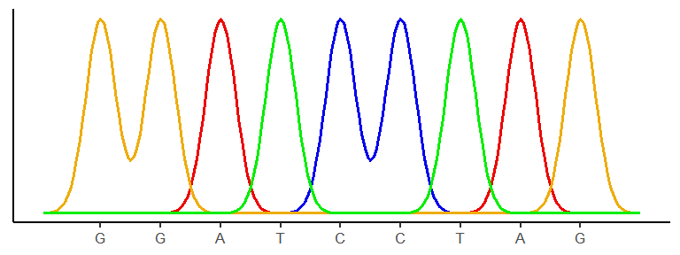

```r
draw_chromatogram(sangr_data, palette = "Geneious")
```

If you prefer you can include your own custom colours by passing a 4 element colour vector to the `palette` argument in the order A, C, G, T.

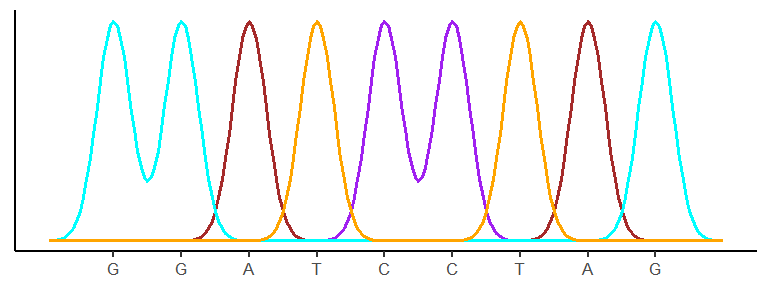

```r
draw_chromatogram(sangr_data, palette = c("brown","purple","cyan","orange"))
```

## Customising plots

The value returned by `draw_chromatogram` is a standard `ggplot2` object so you can add further customisation to it as you see fit. For example all of the plots shown above use the `theme_classic()` theme rather than the default ggplot theme.

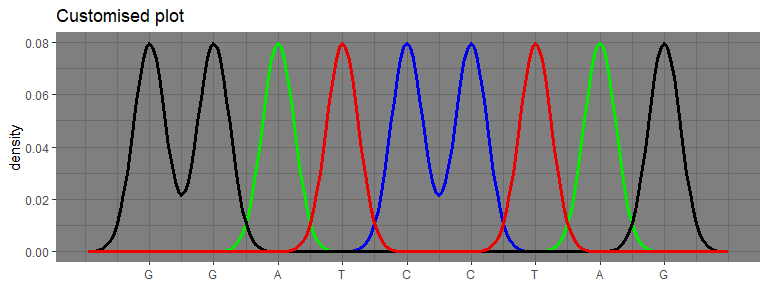

```r
draw_chromatogram(sangr_data) +
  theme_dark()+
  ggtitle("Customised plot") +
  xlab(NULL)
```